# Machine Learning I : Capstone Project

**Coded By:** Chang Oh  
**Kaggle:** https://www.kaggle.com/datasets/zubairmustafa/shopping-mall-customer-segmentation-data/data \

**Comments and/ or concerns?**  
As with most data, it would have been better if there were more features, but because it’s simple, it’s better for me to try algorithms with my understanding. Data might be flawed considering the usability score of 9.41.

## Import libraries and place dataset to dataframe

```python
import pandas as pd
import numpy as np
import matplotlib.pyplot as plt
import seaborn as sns


# GOOGLE DRIVE
#from google.colab import drive
#drive.mount('/content/drive')
#df = pd.read_csv('/content/drive/MyDrive/Colab Notebooks/Shopping Mall Customer Segmentation Data .csv')
# JUPYTER
df = pd.read_csv('Shopping Mall Customer Segmentation Data .csv')
```

## EDA

```python
df.head()
```

|  | Customer ID | Age | Gender | Annual Income | Spending Score |
| --- | --- | --- | --- | --- | --- |
| 0 | d410ea53-6661-42a9-ad3a-f554b05fd2a7 | 30 | Male | 151479 | 89 |
| 1 | 1770b26f-493f-46b6-837f-4237fb5a314e | 58 | Female | 185088 | 95 |
| 2 | e81aa8eb-1767-4b77-87ce-1620dc732c5e | 62 | Female | 70912 | 76 |
| 3 | 9795712a-ad19-47bf-8886-4f997d6046e3 | 23 | Male | 55460 | 57 |
| 4 | 64139426-2226-4cd6-bf09-91bce4b4db5e | 24 | Male | 153752 | 76 |

```python
df.tail()
```

|  | Customer ID | Age | Gender | Annual Income | Spending Score |
| --- | --- | --- | --- | --- | --- |
| 15074 | a0504768-a85f-4930-ac24-55bc8e4fec9e | 29 | Female | 97723 | 30 |
| 15075 | a08c4e0e-d1fe-48e7-9366-aab11ae409cd | 22 | Male | 73361 | 74 |
| 15076 | 0e87c25a-268c-401a-8ba1-7111dcde6f1a | 18 | Female | 112337 | 48 |
| 15077 | 5f388cbe-3373-4e16-b743-38f508f2249f | 26 | Female | 94312 | 5 |
| 15078 | b8b8f561-ebca-4401-8afe-544c906554ba | 19 | Male | 78045 | 2 |

Customer ID is not needed for any purpose.  
Gender will need onehotencoding

```python
df = df.drop('Customer ID', axis=1)
df
```

|  | Age | Gender | Annual Income | Spending Score |
| --- | --- | --- | --- | --- |
| 0 | 30 | Male | 151479 | 89 |
| 1 | 58 | Female | 185088 | 95 |
| 2 | 62 | Female | 70912 | 76 |
| 3 | 23 | Male | 55460 | 57 |
| 4 | 24 | Male | 153752 | 76 |
| ... | ... | ... | ... | ... |
| 15074 | 29 | Female | 97723 | 30 |
| 15075 | 22 | Male | 73361 | 74 |
| 15076 | 18 | Female | 112337 | 48 |
| 15077 | 26 | Female | 94312 | 5 |
| 15078 | 19 | Male | 78045 | 2 |

15079 rows × 4 columns

Apply onehotencoding for gender(male and female)  
get_dummies is used

```python
df_encoded = df.copy()
df_encoded = pd.get_dummies(data=df_encoded, columns=['Gender'], drop_first=True)
df_encoded['Gender_Male'] = df_encoded['Gender_Male'].astype(int)
df_encoded
```

|  | Age | Annual Income | Spending Score | Gender_Male |
| --- | --- | --- | --- | --- |
| 0 | 30 | 151479 | 89 | 1 |
| 1 | 58 | 185088 | 95 | 0 |
| 2 | 62 | 70912 | 76 | 0 |
| 3 | 23 | 55460 | 57 | 1 |
| 4 | 24 | 153752 | 76 | 1 |
| ... | ... | ... | ... | ... |
| 15074 | 29 | 97723 | 30 | 0 |
| 15075 | 22 | 73361 | 74 | 1 |
| 15076 | 18 | 112337 | 48 | 0 |
| 15077 | 26 | 94312 | 5 | 0 |
| 15078 | 19 | 78045 | 2 | 1 |

15079 rows × 4 columns

First column is dropped to prevent multicollinearity  
multicollinearity means high correlation between independent variables  
unnecessary correlation leads to inaccurate prediction

```python
print(f'There are {df.shape[0]} rows and {df.shape[1]} columns.')
```

```
There are 15079 rows and 4 columns.
```

There is adequate rows and columns to do proper train and test model

```python
df_encoded.describe().T
```

|  | count | mean | std | min | 25% | 50% | 75% | max |
| --- | --- | --- | --- | --- | --- | --- | --- | --- |
| Age | 15079.0 | 54.191591 | 21.119207 | 18.0 | 36.0 | 54.0 | 72.0 | 90.0 |
| Annual Income | 15079.0 | 109742.880562 | 52249.425866 | 20022.0 | 64141.0 | 109190.0 | 155008.0 | 199974.0 |
| Spending Score | 15079.0 | 50.591617 | 28.726977 | 1.0 | 26.0 | 51.0 | 75.0 | 100.0 |
| Gender_Male | 15079.0 | 0.503681 | 0.500003 | 0.0 | 0.0 | 1.0 | 1.0 | 1.0 |

```python
spending_df = df_encoded[df_encoded['Spending Score'] > 50]
spending_df.describe().T
```

|  | count | mean | std | min | 25% | 50% | 75% | max |
| --- | --- | --- | --- | --- | --- | --- | --- | --- |
| Age | 7568.0 | 54.165301 | 21.146197 | 18.0 | 36.00 | 54.0 | 73.0 | 90.0 |
| Annual Income | 7568.0 | 110072.234672 | 52071.491179 | 20022.0 | 65136.25 | 110053.0 | 155006.0 | 199974.0 |
| Spending Score | 7568.0 | 75.309989 | 14.505873 | 51.0 | 63.00 | 75.0 | 88.0 | 100.0 |
| Gender_Male | 7568.0 | 0.505285 | 0.500005 | 0.0 | 0.00 | 1.0 | 1.0 | 1.0 |

About half/half is Male/Female  
average age is 54, but there is spread of age groups  
income ranges from 20k to 200k  
speading score ranges from 1 to 100 and average of 50.59

```python
df.info()
```

```
<class 'pandas.core.frame.DataFrame'>
RangeIndex: 15079 entries, 0 to 15078
Data columns (total 4 columns):
 #   Column          Non-Null Count  Dtype
---  ------          --------------  -----
 0   Age             15079 non-null  int64
 1   Gender          15079 non-null  object
 2   Annual Income   15079 non-null  int64
 3   Spending Score  15079 non-null  int64
dtypes: int64(3), object(1)
memory usage: 471.3+ KB
```

No visible null values  
Gender will be int64 after onehotencoding

```python
df.isnull().sum()
```

```
Age               0
Gender            0
Annual Income     0
Spending Score    0
dtype: int64
```

As expected, no null values

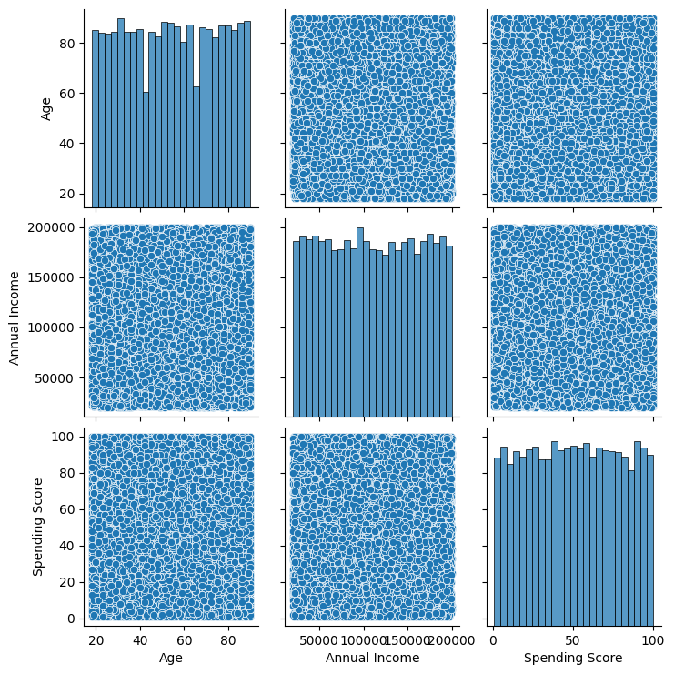

```python
sns.pairplot(data=df)
```

Age, Annual Income, and Spending Score are very evenly spread

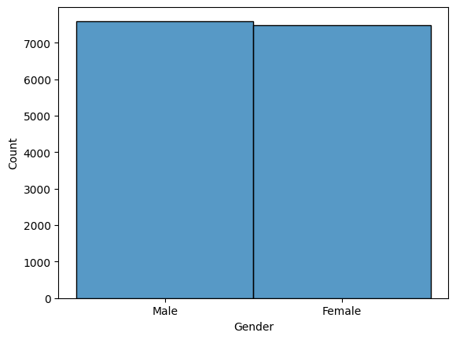

```python
sns.histplot(data=df, x='Gender')
```

Slightly more Male

```python
gender_difference = (df.Gender == 'Male').sum() - (df.Gender == 'Female').sum()
print(f'there are {gender_difference} more male than female out of {df.Gender.shape[0]}')
```

```
there are 111 more male than female out of 15079
```

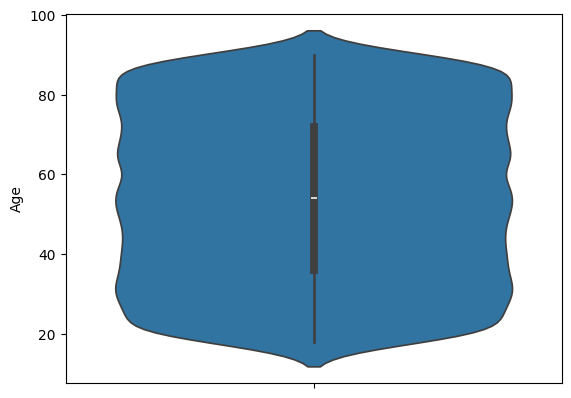

```python
sns.violinplot(data=df, y='Age')
```

Age is pretty well spreadout, not as many children are seen

```python
(df.Age < 18).sum()
```

```
0
```

Infact, there are no children on data, meaning it's left out from its dataset

```python
df_encoded.corr()
```

|  | Age | Annual Income | Spending Score | Gender_Male |
| --- | --- | --- | --- | --- |
| Age | 1.000000 | 0.004776 | -0.008251 | 0.002034 |
| Annual Income | 0.004776 | 1.000000 | 0.003234 | -0.003038 |
| Spending Score | -0.008251 | 0.003234 | 1.000000 | 0.006703 |
| Gender_Male | 0.002034 | -0.003038 | 0.006703 | 1.000000 |

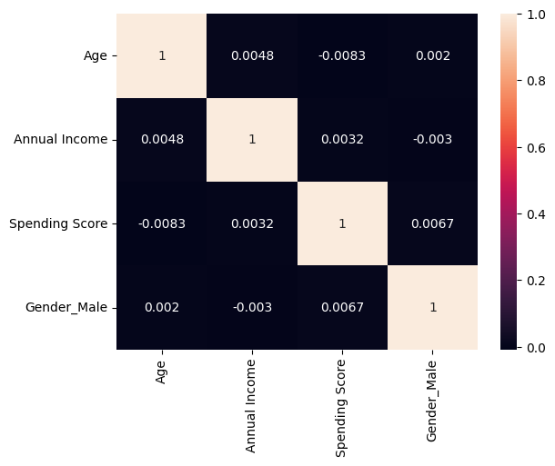

```python
sns.heatmap(df_encoded.corr(), annot=True)
```

None of the variables have any meaningful correlation

Summary EDA:  
So far, the data for Age, Annual Income, Spending Score, and Gender are evenly spread.  
There is no correlation between variables which is concerning when it comes to training and testing the model for insights

## Create Model and Find Metrics

Ensemble Learning: K-Means Clustering  
Hierarchical Clustering  
Principal Analysis Component Analysis (PCA)  
silhouette score (metrics)

```python
from sklearn.cluster import KMeans
from sklearn.decomposition import PCA
from sklearn.preprocessing import StandardScaler
from sklearn.metrics import silhouette_score
from scipy.cluster.hierarchy import dendrogram, linkage
```

Library Import

```python
# Preprocess with Scaler
scaler = StandardScaler()
data_scaled = scaler.fit_transform(df_encoded.select_dtypes(include=[np.number]))
```

```python
# PCA for dimensionality reduction
pca = PCA(n_components=2)
data_pca = pca.fit_transform(data_scaled)
```

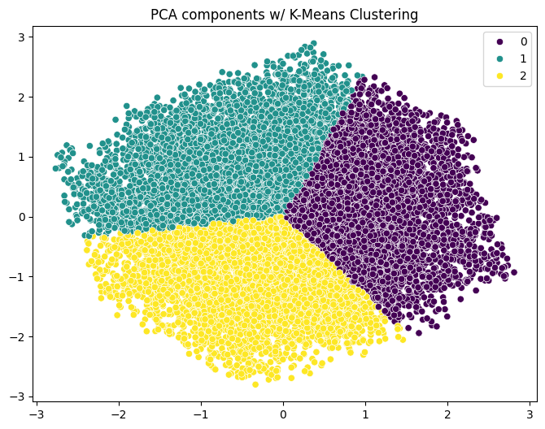

```python
# K-Means Clustering
kmeans = KMeans(n_clusters=3, random_state=42)
kmeans_labels = kmeans.fit_predict(data_pca)

# PCA components w/ K-Means Clustering
plt.figure(figsize=(8, 6))
sns.scatterplot(x=data_pca[:, 0], y=data_pca[:, 1], hue=kmeans_labels, palette='viridis')
plt.title('PCA components w/ K-Means Clustering')
plt.show()
```

Silhouette Score 0.34 w/ 3 clusters and PCA component = 2  
Shows that there is relationship in each group, but it's difficult to derive an insight from clustering other than that it has shape of single major cluster

```
Silhouette Score for K-Means: 0.34333298213491614
```

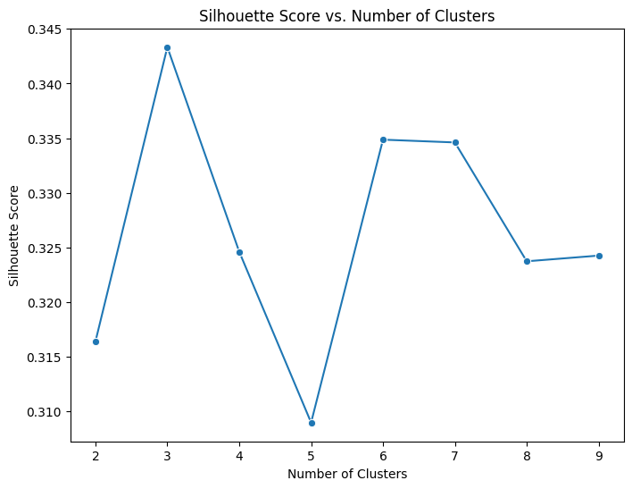

```python
# Silhouette Score
kmeans_silhouette = silhouette_score(data_pca, kmeans_labels)
print(f'Silhouette Score for K-Means: {kmeans_silhouette}')


# Silhouette scores for different numbers of clusters
silhouette_scores = []
for n_clusters in range(2, 10):
    kmeans = KMeans(n_clusters=n_clusters, random_state=42)
    labels = kmeans.fit_predict(data_pca)
    score = silhouette_score(data_pca, labels)
    silhouette_scores.append(score)

# Plot Silhouette scores
plt.figure(figsize=(8, 6))
sns.lineplot(x=range(2, 10), y=silhouette_scores, marker='o')
plt.title('Silhouette Score vs. Number of Clusters')
plt.xlabel('Number of Clusters')
plt.ylabel('Silhouette Score')
plt.show()
```

It's not a linear relationship silhouette score / clusters

Takes 208 second!

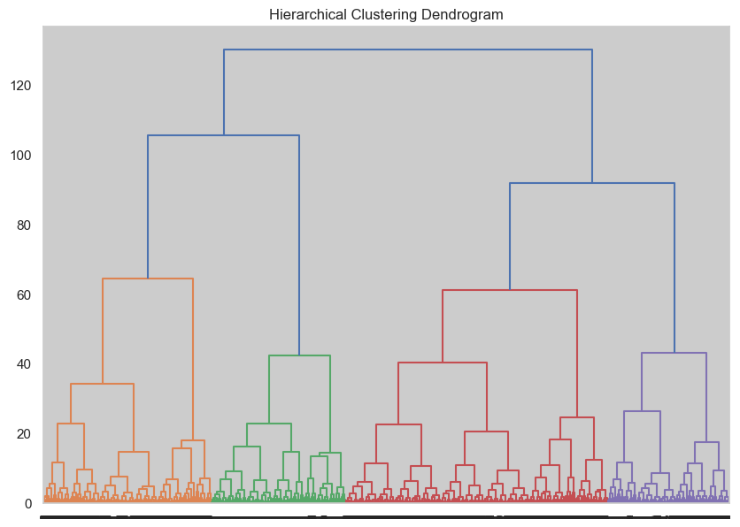

```python
# Hierarchical Clustering (already provided, but can be visualized using seaborn style)
linked = linkage(data_pca, method='ward')
sns.set(style='whitegrid')  # Applying seaborn style
plt.figure(figsize=(10, 7))
dendrogram(linked, orientation='top', labels=kmeans_labels.astype(str), distance_sort='descending')
plt.title('Hierarchical Clustering Dendrogram')
plt.show()
```

### Summary

No outliers and values are evenly spread  
No findings of Correlation through heatmap  
Visually, there is single meaningful cluster  
Clusterwise, three cluster gives highest silhouette score  
PCA component = 2 gives organized cluster visualization  
About half/half is Male/Female  
average age is 54, but there is spread of age groups  
income ranges from 20k to 200k  
speading score ranges from 1 to 100 and average of 50.59  
It's not a linear relationship silhouette score vs cluster  
Infact, there are no children on data, meaning it's left out from its dataset